# Model basics

2023-10-10

## Model basics

モデルを作る基本となる理論

### 準備

```r
library(tidyverse)
library(modelr)
options(na.action = na.warn)
```

> モデルの目的は真実を明らかにすることではない  
> 役に立つ近似を見つけることだ

## 23.1 Introduction

## モデルを作る手順

### Step1 Model Familyを決める

- 直線 or 二次曲線 or etc.
- 説明変数
- データが持つパターンを捕らえる

### Step2 Model Fit

- Model Familyのうち最も良いモデルを採用する
- 良さ ⇒ 訓練データを使った予測結果と実際が一番近い
- 近さ ⇒ 基準を決める(e.g. 二乗誤差)
- 機械学習ではtrainingともいう

## 23.2 A simple model

単純なモデルを使って直線モデル当てはめの基本

## テストデータ

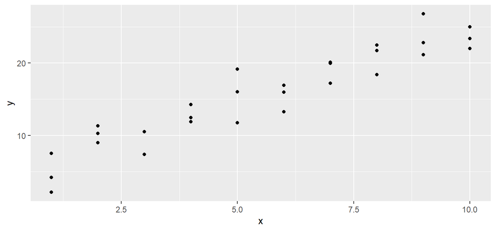

```r
ggplot(sim1, aes(x, y)) + geom_point()
```

直線的な関係がありそうだ \[ y=a_0+a_1x \]

## 250個のテキトーな直線

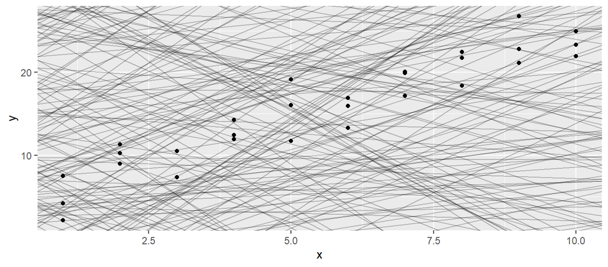

```r
models <- tibble(a1 = runif(250, -20, 40), a2 = runif(250, -5, 5))
ggplot(sim1, aes(x, y)) +
  geom_abline(aes(intercept = a1, slope = a2), data = models, alpha = 1/4) +
  geom_point()
```

このうちどれが良いモデルだろうか？

## モデルによる予測

```r
model1 <- function(a, data) {
  a[1] + data$x * a[2]
}
model1(c(7, 1.5), sim1)
```

```
##  [1]  8.5  8.5  8.5 10.0 10.0 10.0 11.5 11.5 11.5 13.0 13.0 13.0 14.5 14.5 14.5
## [16] 16.0 16.0 16.0 17.5 17.5 17.5 19.0 19.0 19.0 20.5 20.5 20.5 22.0 22.0 22.0
```

- `a[1]`: 切片
- `a[2]`: 傾き
- `data`: data.frameでx列が説明変数の実データ

## モデル予測の誤差

```r
## RMSE
measure_distance <- function(mod, data) {
  diff <- data$y - model1(mod, data)
  sqrt(mean(diff ^2))
}
measure_distance(c(7, 1.5), sim1)
```

```
## [1] 2.665212
```

\[ \mathrm{RMSE} = \sqrt{\frac{1}{N}\sum_{i=1}^N \left(y_i - (a_0 + a_1 x)\right)^2} \]

## 全モデルの予測誤差

```r
sim1_dist <- function(a1, a2) {
  measure_distance(c(a1, a2), sim1)
}
models <- models %>% mutate(dist = purrr::map2_dbl(a1, a2, sim1_dist))
models
```

```
## # A tibble: 250 × 3
##       a1     a2  dist
##    <dbl>  <dbl> <dbl>
##  1 -5.29 -0.422 24.3
##  2 18.0  -4.28  27.9
##  3 12.2   1.92   7.58
##  4 31.5  -0.603 14.9
##  5 -7.21  2.74   8.18
##  6  4.18  0.840  7.85
##  7 38.9   3.31  41.8
##  8 39.8   2.12  36.0
##  9  4.65 -1.60  22.4
## 10 10.5  -4.42  34.8
## # … with 240 more rows
```

## top10モデル

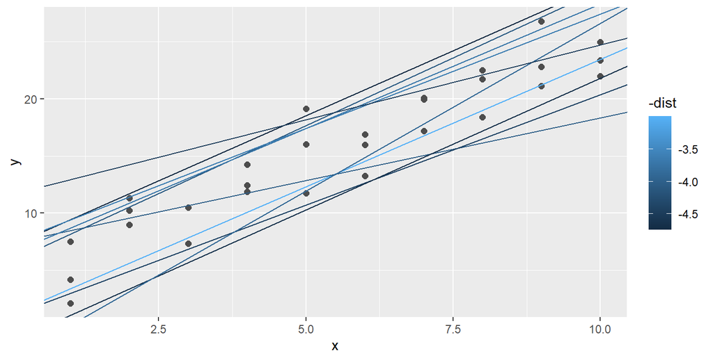

```r
ggplot(sim1, aes(x, y)) + geom_point(size = 2, color = "grey30") +
  geom_abline(
    data = filter(models, rank(dist) <= 10),
    aes(intercept = a1, slope = a2, color = -dist)
  )
```

## 良いパラメータはどれ？

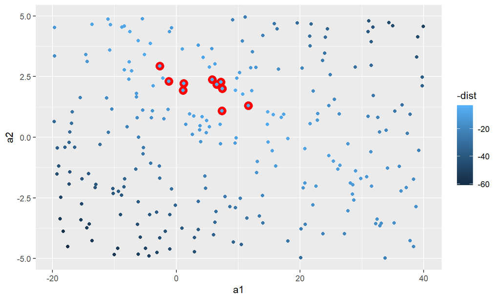

```r
ggplot(models, aes(a1, a2)) +
  geom_point(data = filter(models, rank(dist) <= 10), size = 4, color = "red") +
  geom_point(aes(color = -dist))
```

## 誤差の最適化

```r
best <- optim(c(0, 0), measure_distance, data = sim1)
best$par
```

```
## [1] 4.222248 2.051204
```

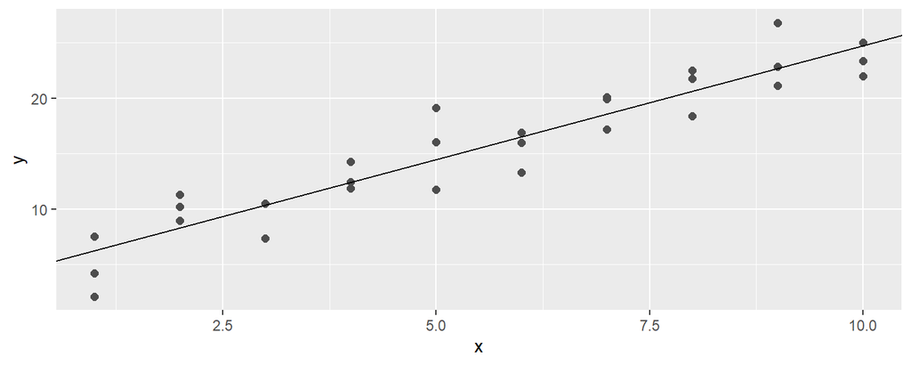

```r
ggplot(sim1, aes(x, y)) +
  geom_point(size = 2, color = "gray30") +
  geom_abline(intercept = best$par[1], slope = best$par[2])
```

## 線形モデルを使った方法

```r
sim1_mod <- lm(y ~ x, data = sim1)
coef(sim1_mod)
```

```
## (Intercept)           x
##    4.220822    2.051533
```

### 実は線形モデルは解析的に解ける

\[\begin{eqnarray} \hat a_0 &=& \bar{y} - \hat a_1\bar{x}\\ \hat a_1 &=& \frac{\sum_{i=1}^N(x_i-\bar x)(y_i-\bar y)}{\sum_{i=1}^N(x_i-\bar x)^2} \end{eqnarray}\]

## 23.2.1 Exercises

## 23.3 Visualising models

作ったモデルを理解したい

- 予測値: モデルが捉えたもの
- 残差: モデルが捉えなかったもの

線形モデルに限らずすべての予測モデルで使える考え方

## 23.3.1 Prediction

モデルが捉えたもの

## `modelr::data_grid()`

### Usage

```r
data_grid(data, ..., .model = NULL)
```

### Arguments

| **data** | data.frame |
| --- | --- |
| **…** | `tidyr::expand()` に渡すパラメータ |
| **.model** | もし設定された場合、モデルに使われている変数も出力する |

### Value

`data` の指定された変数について実データの値の取る範囲に基づいてグリッドを作る。 作られたグリッドがデータフレームとして返ってくる

## 下準備

```r
grid <- sim1 %>% data_grid(x)
grid
```

```
## # A tibble: 10 × 1
##        x
##    <int>
##  1     1
##  2     2
##  3     3
##  4     4
##  5     5
##  6     6
##  7     7
##  8     8
##  9     9
## 10    10
```

```r
# Remember
sim1
```

```
## # A tibble: 30 × 2
##        x     y
##    <int> <dbl>
##  1     1  4.20
##  2     1  7.51
##  3     1  2.13
##  4     2  8.99
##  5     2 10.2
##  6     2 11.3
##  7     3  7.36
##  8     3 10.5
##  9     3 10.5
## 10     4 12.4
## # … with 20 more rows
```

## `modelr::add_predictions()`

### Usage

```r
add_predictions(data, model, var = "pred", type = NULL)
```

### Arguments

| **data** | 予測をする対象になるデータ(data.frame) |
| --- | --- |
| **model** | 予測を行うモデル |
| **var** | 予測を出力する列名 |
| **type** | 予測タイプ。通常は自動設定される |

### Value

`data` で定められたdata.frameに予測列を追加したdata.frame

## 予測を得る

```r
# sim1_mod <- lm(y~x, data = sim1)
grid <- grid %>%
  add_predictions(sim1_mod)
grid
```

```
## # A tibble: 10 × 2
##        x  pred
##    <int> <dbl>
##  1     1  6.27
##  2     2  8.32
##  3     3 10.4
##  4     4 12.4
##  5     5 14.5
##  6     6 16.5
##  7     7 18.6
##  8     8 20.6
##  9     9 22.7
## 10    10 24.7
```

## 予測能力を可視化

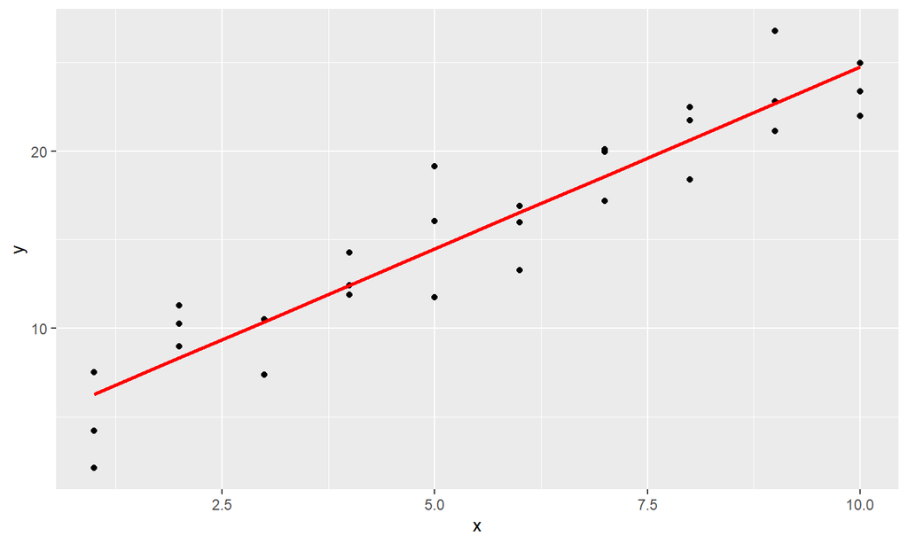

```r
ggplot(sim1, aes(x)) +
  geom_point(aes(y = y)) +
  geom_line(aes(y = pred), data = grid, color = "red", size = 1)
```

## 23.3.2 Residuals

モデルが捉えなかったもの

## `modelr::add_residuals`

### Usage

```r
add_residuals(data, model, var = "resid")
```

### Arguments

| **data** | 予測する対象になるデータ(data.frame) |
| --- | --- |
| **model** | 予測を行うモデル |
| **var** | 予測を出力する列名 |

### Value

`data` で定められたdata.frameに予測誤差を追加したdata.frame

## 残差を得る

```r
sim1 <- sim1 %>%
  add_predictions(sim1_mod) %>%  #Remember
  add_residuals(sim1_mod)
sim1
```

```
## # A tibble: 30 × 4
##        x     y  pred    resid
##    <int> <dbl> <dbl>    <dbl>
##  1     1  4.20  6.27 -2.07
##  2     1  7.51  6.27  1.24
##  3     1  2.13  6.27 -4.15
##  4     2  8.99  8.32  0.665
##  5     2 10.2   8.32  1.92
##  6     2 11.3   8.32  2.97
##  7     3  7.36 10.4  -3.02
##  8     3 10.5  10.4   0.130
##  9     3 10.5  10.4   0.136
## 10     4 12.4  12.4   0.00763
## # … with 20 more rows
```

## 残差の可視化１ (誤差分布)

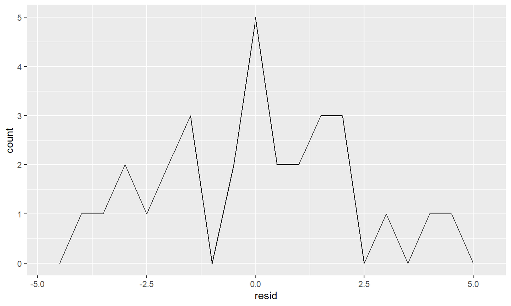

```r
ggplot(sim1, aes(resid)) +
  geom_freqpoly(binwidth = 0.5)
```

## 残差の可視化２ (vs説明変数)

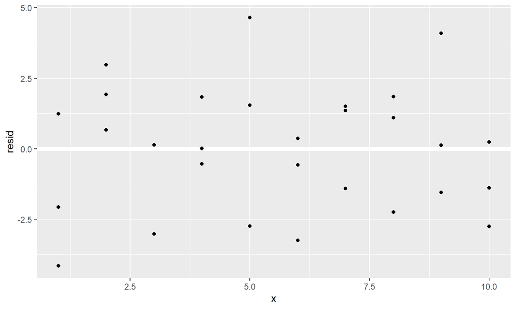

```r
ggplot(sim1, aes(x, resid)) +
  geom_ref_line(h = 0) +
  geom_point()
```

## 23.3.3 Exercises

## 23.4 Formulas and model families

Formulaを使ってモデル族(Model family)を設定する

### モデル族 = 統計モデル + モデル式(Formula)

- 統計モデルの例： 線形モデル、ニューラルネットワーク
- モデル式：要するに説明変数
- 機械学習の分野ではモデル式の設定を **特長量エンジニアリング** と言ったりする

### 目次

- 基本の説明変数
- 離散値の説明変数
- 相互作用
- 変数の変換

## Model Formula

Rの多くのモデル関数ではFormulaという文法でモデル式を設定できる

### 文法： 目的変数 ~ 説明変数の構造

### 例

線形モデルのモデル関数 `lm` で Formula `y ~ x` を指定する

```r
lm(formula = y~x, data = sim1)
```

これは \(y\) を \(a_0+a_1 x\) というモデル族を使って予測するということ

## Model Formulaの調整

| formula | linear model | 説明 |
| --- | --- | --- |
| `y~x` | \(y\sim a_0+a_1x\) | 標準的な線形回帰 |
| `y~x-1` | \(y\sim a_1x\) | 切片ゼロ。比例関係 |
| `y~x1+x2` | \(y\sim a_0+a_1x_1+a_2x_2\) | 二変数。いわゆる重回帰 |

## 21.4.1 Categorical variables

カテゴリー変数（質的変数）で回帰分析する

## 文字列変数を説明変数にFormulaが書ける(便利)

```r
df <- tribble(
  ~sex, ~response,
  "male", 1,
  "female", 2,
  "male", 1
)
model_matrix(df, response ~ sex)
```

```
## # A tibble: 3 × 2
##   `(Intercept)` sexmale
##           <dbl>   <dbl>
## 1             1       1
## 2             1       0
## 3             1       1
```

sexfemale列は無くていいのか？

## 数式で表現すると

\[ y \sim a_0 + a_1 x \] where \[ x = \left\{ \begin{array}{ll} 1 & (\mathrm{sex = male})\\ 0& (\mathrm{sex = female}) \end{array} \right. \]

### もしくは

\[ y \sim \left\{ \begin{array}{ll} a_0 + a_1 & (\mathrm{sex} = \mathrm{male})\\ a_0 & (\mathrm{sex} = \mathrm{female})\end{array}\right. \]

## 言葉で表現すると

- \(a_0\)は`sex=female`の`y`の平均値
- \(a_1\)は`sex=male`の`y`の平均値と`sex=female`の`y`の平均値\(a_0\)との差

### 数式再掲

\[ y \sim \left\{ \begin{array}{ll} a_0 + a_1 & (\mathrm{sex} = \mathrm{male})\\ a_0 & (\mathrm{sex} = \mathrm{female})\end{array}\right. \]

## お題

```r
sim2
```

```
## # A tibble: 40 × 2
##    x          y
##    <chr>  <dbl>
##  1 a      1.94
##  2 a      1.18
##  3 a      1.24
##  4 a      2.62
##  5 a      1.11
##  6 a      0.866
##  7 a     -0.910
##  8 a      0.721
##  9 a      0.687
## 10 a      2.07
## # … with 30 more rows
```

```r
mod2 <- lm(y ~ x, data = sim2)
grid <- sim2 %>%
  data_grid(x) %>%
  add_predictions(mod2)
grid
```

```
## # A tibble: 4 × 2
##   x      pred
##   <chr> <dbl>
## 1 a      1.15
## 2 b      8.12
## 3 c      6.13
## 4 d      1.91
```

## 分析

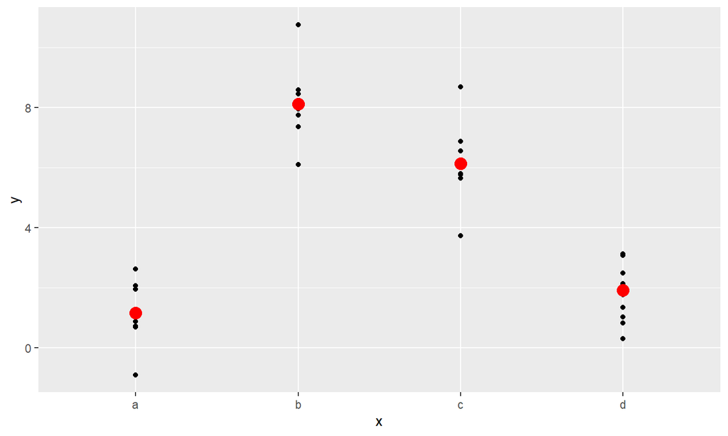

```r
ggplot(sim2, aes(x)) +
  geom_point(aes(y = y)) +
  geom_point(data = grid, aes(y = pred), color = "red", size = 4)
```

## 23.4.2 交互作用(連続-カテゴリ)

説明変数２つ \(x_1\)(連続) と \(x_2\)(カテゴリ) で回帰分析するとき、２変数にシナジーがある

### Model Formula

```r
y ~ x1 * x2
```

### 数式(二値の場合)

\[ y \sim \left\{ \begin{array}{ll} a_0 + a_1 x_1 + a_21 + a_3 x_1 1 &(x_2 = \mathrm{value1})\\ a_0 + a_1 x_1 + a_2 0 + a_3 x_1 0 & (x_2 = \mathrm{value2}) \end{array} \right. \]

## お題

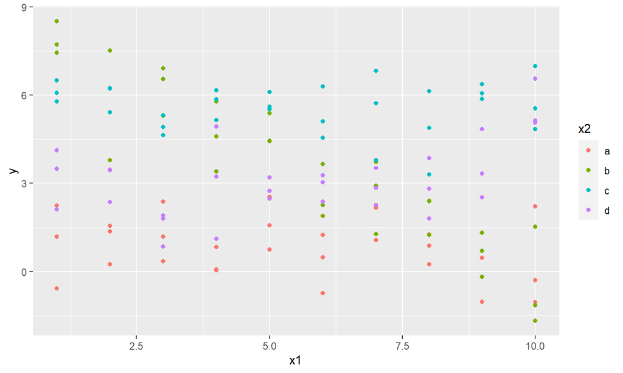

```r
ggplot(sim3, aes(x1, y)) +
  geom_point(aes(color = x2))
```

## 分析

```r
mod1 <- lm(y ~ x1 + x2, data = sim3) #交互作用無しの回帰分析
mod2 <- lm(y ~ x1 * x2, data = sim3) #交互作用有りの回帰分析
grid <- sim3 %>%
  data_grid(x1, x2) %>%
  gather_predictions(mod1, mod2)
grid
```

```
## # A tibble: 80 × 4
##    model    x1 x2     pred
##    <chr> <int> <fct> <dbl>
##  1 mod1      1 a      1.67
##  2 mod1      1 b      4.56
##  3 mod1      1 c      6.48
##  4 mod1      1 d      4.03
##  5 mod1      2 a      1.48
##  6 mod1      2 b      4.37
##  7 mod1      2 c      6.28
##  8 mod1      2 d      3.84
##  9 mod1      3 a      1.28
## 10 mod1      3 b      4.17
## # … with 70 more rows
```

## モデルの可視化

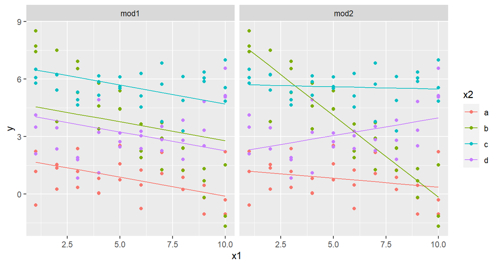

```r
ggplot(sim3, aes(x1, y, color = x2)) +
  geom_point() +
  geom_line(data = grid, aes(y = pred)) +
  facet_wrap(~ model)
```

## 残差の可視化

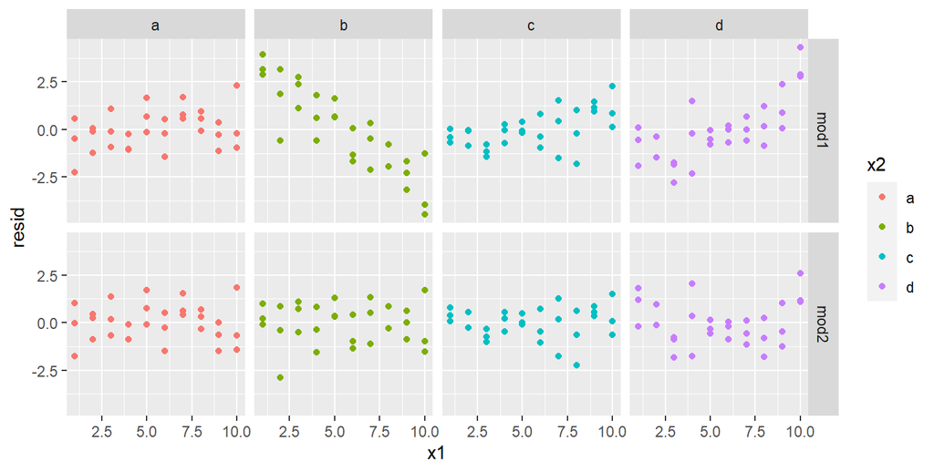

```r
sim3 %>%
  gather_residuals(mod1, mod2) %>%
  ggplot(aes(x1, resid, color = x2)) +
  geom_point() +
  facet_grid(model ~ x2)
```

## 23.4.3 交互作用（連続-連続)

説明変数２つ \(x_1\)(連続), \(x_2\)(連続) で回帰分析するとき、２変数にシナジーがある

### Model formula

```r
y ~ x1 * x2
```

### 数式

\[ y \sim a_0 + a_1 x_1 + a_2 x_2 + a_3 x_1x_2 \]

## お題

```r
sim4
```

```
## # A tibble: 300 × 4
##       x1     x2   rep       y
##    <dbl>  <dbl> <int>   <dbl>
##  1    -1 -1         1  4.25
##  2    -1 -1         2  1.21
##  3    -1 -1         3  0.353
##  4    -1 -0.778     1 -0.0467
##  5    -1 -0.778     2  4.64
##  6    -1 -0.778     3  1.38
##  7    -1 -0.556     1  0.975
##  8    -1 -0.556     2  2.50
##  9    -1 -0.556     3  2.70
## 10    -1 -0.333     1  0.558
## # … with 290 more rows
```

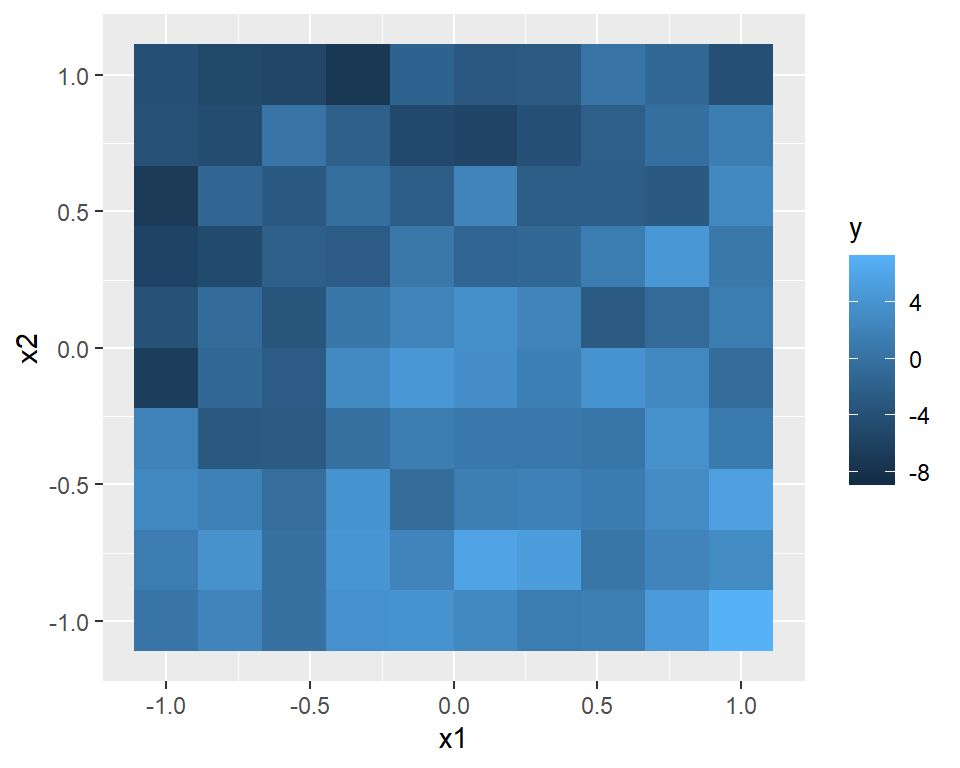

```r
ggplot(sim4, aes(x1, x2)) +
  geom_tile(aes(fill = y))
```

## 分析

```r
mod1 <- lm(y ~ x1 + x2, data = sim4) #交互作用なし
mod2 <- lm(y ~ x1 * x2, data = sim4) #交互作用あり
grid <- sim4 %>%
  data_grid( x1 = seq_range(x1, 5), x2 = seq_range(x2, 5) ) %>%
  gather_predictions(mod1, mod2)
grid
```

```
## # A tibble: 50 × 4
##    model    x1    x2   pred
##    <chr> <dbl> <dbl>  <dbl>
##  1 mod1   -1    -1    0.996
##  2 mod1   -1    -0.5 -0.395
##  3 mod1   -1     0   -1.79
##  4 mod1   -1     0.5 -3.18
##  5 mod1   -1     1   -4.57
##  6 mod1   -0.5  -1    1.91
##  7 mod1   -0.5  -0.5  0.516
##  8 mod1   -0.5   0   -0.875
##  9 mod1   -0.5   0.5 -2.27
## 10 mod1   -0.5   1   -3.66
## # … with 40 more rows
```

## モデルの可視化

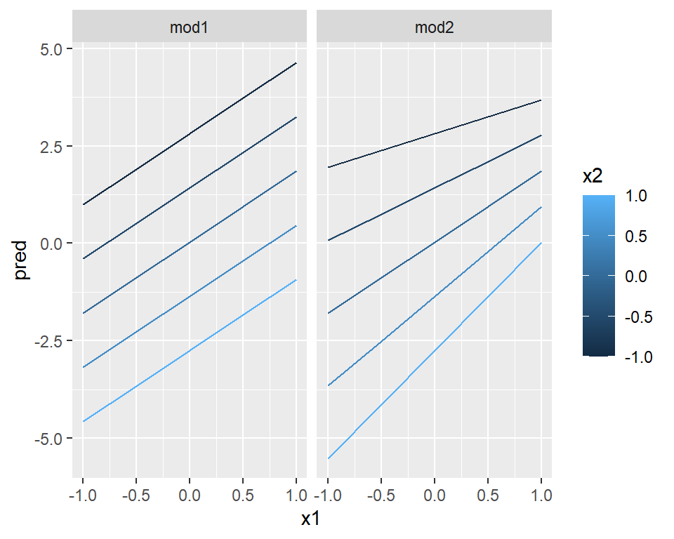

```r
ggplot(grid, aes(x1, pred)) +
  geom_line(aes(color = x2, group = x2)) +
  facet_wrap(~ model)
```

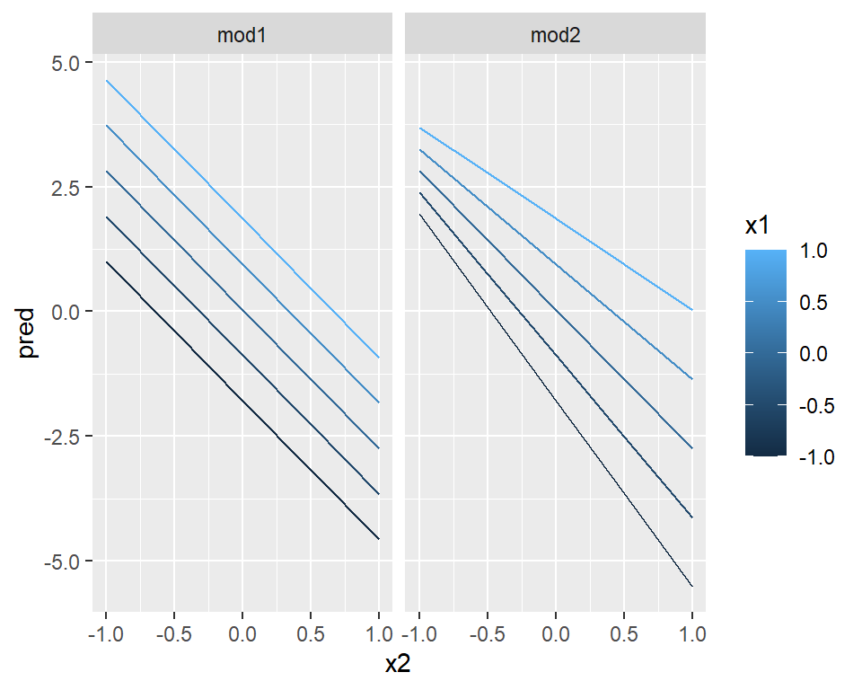

```r
ggplot(grid, aes(x2, pred)) +
  geom_line(aes(color = x1, group = x1)) +
   facet_wrap(~ model)
```

## 残差の可視化

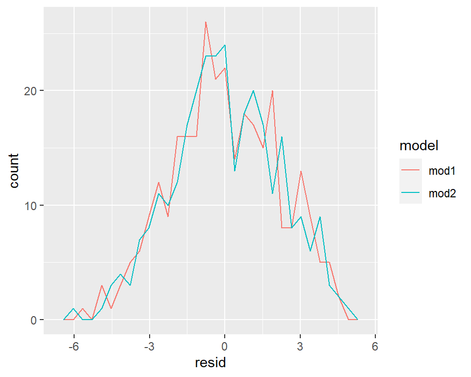

```r
sim4 <- gather_residuals(sim4, mod1, mod2)
ggplot(sim4, aes(x = resid))  +
  geom_freqpoly(aes(color = model))
```

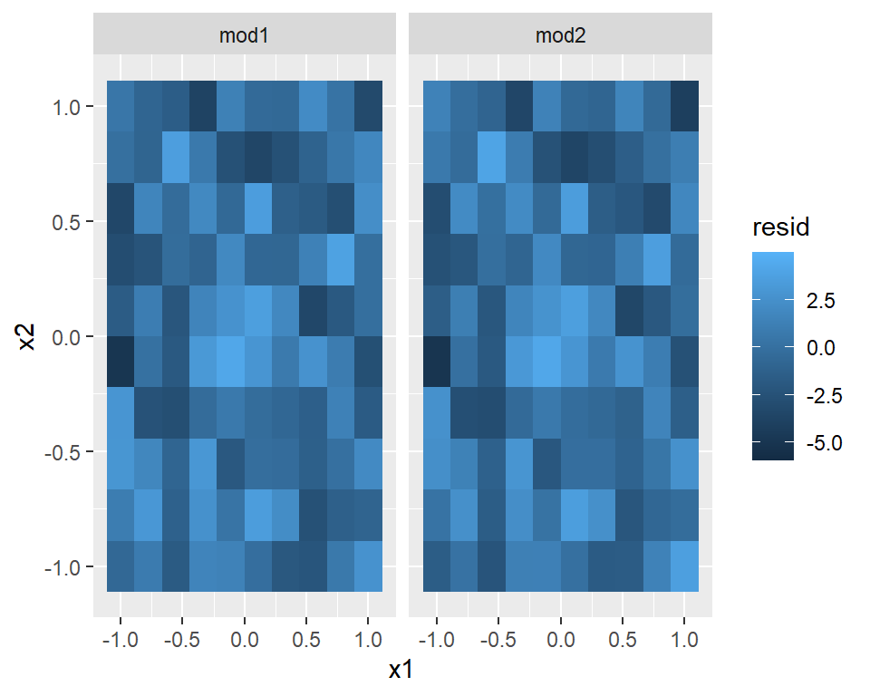

```r
ggplot(sim4, aes(x1, x2))  +
  geom_tile(aes(fill = resid)) +
  facet_wrap(~model)
```

## モデルの統計的な指標たち

```r
summary(mod2)
```

```
##
## Call:
## lm(formula = y ~ x1 * x2, data = sim4)
##
## Residuals:
##     Min      1Q  Median      3Q     Max
## -5.9629 -1.4165 -0.1032  1.4284  4.9957
##
## Coefficients:
##             Estimate Std. Error t value Pr(>|t|)
## (Intercept)  0.03546    0.11995   0.296  0.76772
## x1           1.82167    0.18792   9.694  < 2e-16 ***
## x2          -2.78252    0.18792 -14.807  < 2e-16 ***
## x1:x2        0.95228    0.29441   3.235  0.00136 **
## ---
## Signif. codes:  0 '***' 0.001 '**' 0.01 '*' 0.05 '.' 0.1 ' ' 1
##
## Residual standard error: 2.078 on 296 degrees of freedom
## Multiple R-squared:  0.5223, Adjusted R-squared:  0.5175
## F-statistic: 107.9 on 3 and 296 DF,  p-value: < 2.2e-16
```

## 23.4.4 変換

説明変数や目的変数を初等関数を使って変換する

### Model formula

```r
I(y) ~ I(x)
```

```
## I(y) ~ I(x)
```

## 具体例

| formula | model | 説明 |
| --- | --- | --- |
| `y~I(x^2)` | \(y\sim a_0+a_1x^2\) | 二乗を使った回帰 |
| `y~poly(x, 3)` | \(y\sim a_0+a_1+a_2x^2+a_3x^3\) | 三次回帰 |
| `I(log(y))~I(log(x))` | \(\log y\sim a_0 + a_1 \log x\) | 対数変換。めちゃくちゃ重要 |

## いろいろと理論的なよもやま話

- 多項式モデル `poly(x, p)` を使って、次数 \(p\) を無限大にすると任意の曲線を近似できるテイラーの定理）
  - 多項式の次元を大きくすると \(x\) が極端に大きいときは急速に大きく/小さく なってうまくいかない
  - またモデルの自由度が高すぎると[過学習/overfitting](https://www.ibm.com/jp-ja/topics/overfitting)して予測はうまくいかない
- ナイスな代案はスプラインを使うこと、特に **自然スプライン** は有益だ
- 自然スプラインとは直線、二次曲線、三次曲線をいい感じに繋いで一つのグラフを作る方法
- `ns(x, p)` という関数を使えば自然スプラインのFormulaが自動的に書けちゃう。ただし \(p\) は自由度

## 23.4.5 Exercises

## 23.5 欠損値

- 欠損値はモデル学習には利用できない
- 選択肢
  - 欠損値のある行をすべて削除してしまう
  - 欠損値を何かの値で代用する（ゼロとか）
  - 欠損値を平均値などで埋める（高級なテクニック）

非常にテクニカルなので詳細は立ち入らない

## 23.6 その他のモデル

- 一般化線形モデル `stats::glm()`
- 一般化加法モデル `mgcv::gam()`
- ペナルティ付き線形モデル（正則化） `glmnet::glmnet()`
- ロバスト線形回帰 `MASS::rlm()`
- 決定木 `rpart::rpart()`
  - [ランダムフォレスト](https://www.ibm.com/jp-ja/topics/random-forest) `randomForest::randomForest()`
  - [勾配ブースティング](https://www.ibm.com/jp-ja/topics/boosting) `xgboost::xgboost()`